# Overengineering 101

### We're talking about training (More Thomas than ML)

Evan Miller, Tax Ventures

#### I used a USB mic to try and record how many trains go past my flat and didn't build a single model.

##### This is my story.

## 1. Why???

- Got given a Raspberry Pi by my sis a few years ago.
  - I've been a Data Scientist for years but never gathered my own data
- Idea #1 find the optimal time for going for a walk such that I'd see as many dogs as possible
- Idea #2 count how many sirens go past my flat
  - Live between Charing Cross and Hammersmith Hospitals, so this number is LARGE
- Idea #3 count how many trains go past my flat (less grim)

https://github.com/evanmiller29/rasp_pi_siren_train_counter

## Confessions

**Before this I'd never gathered my own dataset**

After this I feel like every data scientist should do this. It gives you a lot of humility towards crap data sources

### What does my code do

1. Creates Azure Blob container
2. Gets inputs from the user
   - How long should each file be, how many files do you want to record
   - Technical audio analysis things
3. Finds USB mic
4. Records
5. Saves properties
6. Zips recordings
7. Uploads recordings to Azure

```python
data_dir = "data"

files = os.listdir(data_dir)
json_settings_file = [file for file in files if '.json' in file][0]
audio_files = [file for file in files if '.json' not in file]

with open(os.path.join(data_dir, json_settings_file)) as f:
    json_settings = json.load(f)

pd.DataFrame([json_settings]).T
```

|  | 0 |
| --- | --- |
| form | 8 |
| channel | 1 |
| sample_rate | 44100 |
| chunk_size | 4096 |
| record_secs | 60 |
| usb_audio_device_num | 2 |
| output_dir | /home/pi/Desktop/wav_files/raw_files/202004061233 |
| location | bedroom |

#### Finding Thomas pt.1 - can we use image classification?

##### #2 NOT a train

[figure not shown]

#### Finding Thomas pt.2 - can we use image classification?

#### #4 IS a train

[figure not shown]

### 3. Going from raw to labelled (Label Studio)

Label studio is an Open Source data labelling (go figure) solution. It supports labelling the following data types and is easily extensible:

- Audio
- Image
- Text
- HTML

It doesn't have great Docker support (like Doccano) but they're working on that.

`label-studio start train_sample`

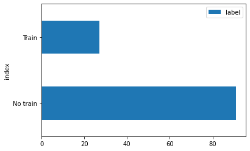

```python
results_df = pd.DataFrame(results)
graph_df = results_df['label'].value_counts().reset_index()

graph_df = graph_df.set_index('index')
graph_df.plot(kind='barh')
```

### Why did I stop this project a bit early?

- I realized that the current approach had it's limitations
  - Creating a training set with one row for each file would be very difficult
  - Audio segmentation would be much better
    - That would require me listening to most of those files again, and I don't have the patience for that
- BUTTTTT, it got me onto my current project of using Arduino sensors + Raspberry Pi to gather data on my indoor garden
  - Temperature, humidity, light sensors etc
    - Wouldn't have been able to do this otherwise